# Storms that Cause the Most Harm to Population Health and the Economy

Liana Principe

9/25/2020

Storms that Cause the Most Harm to Population Health and the Economy

```r
knitr::opts_chunk$set(echo = TRUE)
```

```r
library(dplyr)
```

```r
library(ggplot2)
options(scipen=10000)
storm<- read.csv("~/Downloads/repdata_data_StormData.csv")
```

The records have a lot of data from the past years so it is best to clean the data to make it easier to read and understand the information.

To address the effect on public health, the data was structured by measuring the number of fatalities and injuries that were caused by each storm over the time period of the records, as well as how many times that storm occurred. Once the data is cleaner, the analysis is filtered to specifically focus on the storms that have had at least one fatality and at least one injury.

```r
type<- storm %>% group_by(EVTYPE) %>% summarize(N=n(), Total_Fatalities= sum(FATALITIES, na.rm=TRUE), Total_Injuries=sum(INJURIES, na.rm=TRUE)) %>% arrange(desc(N))
type_num<- type %>% filter(Total_Fatalities>0 & Total_Injuries>0) %>% arrange(desc(N))
```

To find the storms that cause the most harm to the population, the dataset was filtered to find the storms with the most combined fatalities and injuries.

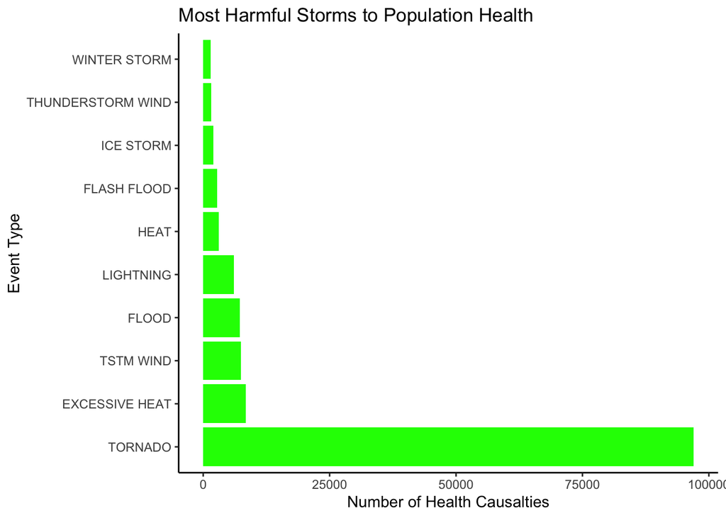

```r
both<- type %>% mutate(Total_Both=Total_Fatalities+Total_Injuries) %>% arrange(desc(Total_Both)) %>% filter(Total_Both>1500)

both %>% ggplot() +
  geom_col(aes(reorder(EVTYPE, -Total_Both), Total_Both), fill="green")+coord_flip()+
  xlab("Event Type")+ylab("Number of Health Causalties") + ggtitle("Most Harmful Storms to Population Health") + theme_classic()
```

This graph shows the top 10 storms that have caused the most damage to population health over the last 50 years. The storms are listed on the left and each bar shows how many combined fatalities and injuries the storm has caused in all of the data. Specifically, the graph shows that Tornados are the leading cause of population health followed by Excessive Heat, and TSTM Wind as the third leading storm.

For our second issue of economics causilties, we scraped the data to find all of the information about property and crop damage. The dataset for econcomic causilties combines the total damage caused that has negatievly impacted our economy.

```r
econ<- storm %>% select(EVTYPE, PROPDMG, CROPDMG) %>% group_by(EVTYPE)%>% summarize(N=n(), Property_Damage=sum(PROPDMG), Crop_Damage=sum(CROPDMG)) %>% filter( Property_Damage>0 & Crop_Damage>0) %>% arrange(desc(N))
```

[figure not shown]

```r
top_econ<- econ[1:12,]
top_econ %>% ggplot() + geom_col(aes(reorder(EVTYPE,-N), N, fill="cyan")) +
  coord_flip()+
  xlab("Storm")+ylab("Property and Crop Damage")+ggtitle("Leading Storms Causing of Economic Consequences")+ theme(plot.title=element_text(hjust=1))
```

```r
v<- c("EXCESSIVE HEAT", "FLASH FLOOD", "FLOOD", "HAIL", "HEAT", "HEAVY RAIN", "HEAVY SNOW", "HIGH WIND", "ICE STORM", "LIGHTNING"," THUNDERSTORM WIND", "THUNDERSTORM WINDS", "TORNADO", "TSTM WIND", "WINTER STORM")
results<- storm %>% filter(EVTYPE %in% v) %>% group_by(EVTYPE) %>% summarize(N=n(), Total_Fatalities= sum(FATALITIES, na.rm=TRUE), Total_Injuries=sum(INJURIES, na.rm=TRUE), Property_Damage=sum(PROPDMG), Crop_Damage=sum(CROPDMG)) %>% arrange(desc(N))
results
```

| EVTYPE | N | Total_Fatalities | Total_Injuries | Property_Damage | Crop_Damage |
| --- | --- | --- | --- | --- | --- |
| HAIL | 288661 | 15 | 1361 | 688693.38 | 579596.28 |
| TSTM WIND | 219940 | 504 | 6957 | 1335965.61 | 109202.60 |
| TORNADO | 60652 | 5633 | 91346 | 3212258.16 | 100018.52 |
| FLASH FLOOD | 54277 | 978 | 1777 | 1420124.59 | 179200.46 |
| FLOOD | 25326 | 470 | 6789 | 899938.48 | 168037.88 |
| THUNDERSTORM WINDS | 20843 | 64 | 908 | 446293.18 | 18684.93 |
| HIGH WIND | 20212 | 248 | 1137 | 324731.56 | 17283.21 |
| LIGHTNING | 15754 | 816 | 5230 | 603351.78 | 3580.61 |
| HEAVY SNOW | 15708 | 127 | 1021 | 122251.99 | 2165.72 |
| HEAVY RAIN | 11723 | 98 | 251 | 50842.14 | 11122.80 |

[output cut: 4 more lines]

The figure above is a list of the top dangerouse storms for public health and for the economy, taken from the two graphs previously. In this table, the data shows the name of the storm, how often that type of storm occurred, total fatalities, total injuries, total property damage, and the total crop damage recorded over the timeline of the original data.